# Model 1:- (APS Failure and Operational Data for Scania Trucks)

#### Introduction

- The dataset consists of data collected from heavy Scania trucks in everyday usage. The system in focus is the Air Pressure system (APS) which generates pressurised air that are utilized in various functions in a truck, such as braking and gear changes. The datasets' positive class consists of component failures for a specific component of the APS system. The negative class consists of trucks with failures for components not related to the APS. The data consists of a subset of all available data, selected by experts.

##### Number of Instances:

- The training set contains 60000 examples in total in which 59000 belong to the negative class and 1000 positive class. The test set contains 16000 examples.

#### Number of Attributes: 171

#### Attribute Information:

- The attribute names of the data have been anonymized for proprietary reasons. It consists of both single numerical counters and histograms consisting of bins with different conditions. Typically the histograms have open-ended conditions at each end. For example if we measuring the ambient temperature "T" then the histogram could be defined with 4 bins where:

  bin 1 collect values for temperature T < -20 bin 2 collect values for temperature T >= -20 and T < 0  
  bin 3 collect values for temperature T >= 0 and T < 20  
  bin 4 collect values for temperature T > 20

  ```
     -20     0      20
  ```

  The attributes are as follows: class, then anonymized operational data. The operational data have an identifier and a bin id, like "Identifier_Bin". In total there are 171 attributes, of which 7 are histogram variabels. Missing values are denoted by "na".

# importing package

```python
#import all the necessary packages.
import matplotlib.pyplot as plt
import numpy as np
import pandas as pd
import warnings
import re

import seaborn as sns
from collections import Counter
from matplotlib import gridspec
from scipy.sparse import hstack
import plotly
import plotly.figure_factory as ff
from plotly.graph_objs import Scatter, Layout
from sklearn.preprocessing import normalize
from xgboost import XGBClassifier
from sklearn.calibration import CalibratedClassifierCV
from sklearn.linear_model import LogisticRegression
from sklearn.metrics import log_loss
from sklearn.metrics import confusion_matrix

plotly.offline.init_notebook_mode(connected=True)
warnings.filterwarnings("ignore")
import pickle
from imblearn.over_sampling import SMOTE
```

# loading the data

```python
train_data = pd.read_csv('Model_1//aps_failure_training_set.csv')
test_data = pd.read_csv('Model_1//aps_failure_test_set.csv')
```

```python
print('Number of data points in train_set : ', train_data.shape[0])
print('Number of features in train_set: ', train_data.shape[1])
print('Features : ', train_data.columns.values)
train_data.head()
```

```
Number of data points in train_set :  60000
Number of features in train_set:  171
Features :  ['class' 'aa_000' 'ab_000' 'ac_000' 'ad_000' 'ae_000' 'af_000' 'ag_000'
 'ag_001' 'ag_002' 'ag_003' 'ag_004' 'ag_005' 'ag_006' 'ag_007' 'ag_008'
 'ag_009' 'ah_000' 'ai_000' 'aj_000' 'ak_000' 'al_000' 'am_0' 'an_000'
 'ao_000' 'ap_000' 'aq_000' 'ar_000' 'as_000' 'at_000' 'au_000' 'av_000'
 'ax_000' 'ay_000' 'ay_001' 'ay_002' 'ay_003' 'ay_004' 'ay_005' 'ay_006'
 'ay_007' 'ay_008' 'ay_009' 'az_000' 'az_001' 'az_002' 'az_003' 'az_004'
 'az_005' 'az_006' 'az_007' 'az_008' 'az_009' 'ba_000' 'ba_001' 'ba_002'
 'ba_003' 'ba_004' 'ba_005' 'ba_006' 'ba_007' 'ba_008' 'ba_009' 'bb_000'
 'bc_000' 'bd_000' 'be_000' 'bf_000' 'bg_000' 'bh_000' 'bi_000' 'bj_000'
 'bk_000' 'bl_000' 'bm_000' 'bn_000' 'bo_000' 'bp_000' 'bq_000' 'br_000'
 'bs_000' 'bt_000' 'bu_000' 'bv_000' 'bx_000' 'by_000' 'bz_000' 'ca_000'
 'cb_000' 'cc_000' 'cd_000' 'ce_000' 'cf_000' 'cg_000' 'ch_000' 'ci_000'
 'cj_000' 'ck_000' 'cl_000' 'cm_000' 'cn_000' 'cn_001' 'cn_002' 'cn_003'
 'cn_004' 'cn_005' 'cn_006' 'cn_007' 'cn_008' 'cn_009' 'co_000' 'cp_000'
 'cq_000' 'cr_000' 'cs_000' 'cs_001' 'cs_002' 'cs_003' 'cs_004' 'cs_005'
 'cs_006' 'cs_007' 'cs_008' 'cs_009' 'ct_000' 'cu_000' 'cv_000' 'cx_000'
 'cy_000' 'cz_000' 'da_000' 'db_000' 'dc_000' 'dd_000' 'de_000' 'df_000'
 'dg_000' 'dh_000' 'di_000' 'dj_000' 'dk_000' 'dl_000' 'dm_000' 'dn_000'
 'do_000' 'dp_000' 'dq_000' 'dr_000' 'ds_000' 'dt_000' 'du_000' 'dv_000'
 'dx_000' 'dy_000' 'dz_000' 'ea_000' 'eb_000' 'ec_00' 'ed_000' 'ee_000'
 'ee_001' 'ee_002' 'ee_003' 'ee_004' 'ee_005' 'ee_006' 'ee_007' 'ee_008'
 'ee_009' 'ef_000' 'eg_000']
```

|  | class | aa_000 | ab_000 | ac_000 | ad_000 | ae_000 | af_000 | ag_000 | ag_001 | ag_002 | ... | ee_002 | ee_003 | ee_004 | ee_005 | ee_006 | ee_007 | ee_008 | ee_009 | ef_000 | eg_000 |
| --- | --- | --- | --- | --- | --- | --- | --- | --- | --- | --- | --- | --- | --- | --- | --- | --- | --- | --- | --- | --- | --- |
| 0 | -0.992188 | 0.117188 | -0.289062 | 0.992188 | -0.007812 | -0.046875 | -0.054688 | -0.007812 | -0.03125 | -0.054688 | ... | 0.687500 | 0.515625 | 0.234375 | 0.070312 | 0.007812 | -0.109375 | -0.140625 | -0.171875 | -0.023438 | -0.023438 |
| 1 | -0.992188 | -0.179688 | -0.289062 | -0.468750 | -0.007812 | -0.046875 | -0.054688 | -0.007812 | -0.03125 | -0.054688 | ... | -0.023438 | -0.062500 | -0.132812 | -0.132812 | -0.187500 | -0.148438 | -0.085938 | -0.140625 | -0.023438 | -0.023438 |
| 2 | -0.992188 | -0.125000 | -0.289062 | -0.468750 | -0.007812 | -0.046875 | -0.054688 | -0.007812 | -0.03125 | -0.054688 | ... | -0.140625 | -0.093750 | -0.015625 | 0.015625 | -0.007812 | -0.109375 | -0.093750 | -0.164062 | -0.023438 | -0.023438 |
| 3 | -0.992188 | -0.406250 | -0.289062 | -0.468750 | -0.007812 | -0.046875 | -0.007812 | -0.007812 | -0.03125 | -0.054688 | ... | -0.382812 | -0.382812 | -0.375000 | -0.351562 | -0.312500 | -0.195312 | -0.304688 | -0.171875 | 0.890625 | 0.992188 |
| 4 | -0.992188 | 0.007812 | -0.289062 | -0.468750 | -0.007812 | -0.046875 | -0.054688 | -0.007812 | -0.03125 | -0.054688 | ... | 0.156250 | 0.031250 | -0.031250 | -0.039062 | -0.046875 | -0.015625 | 0.656250 | -0.148438 | -0.023438 | -0.023438 |

5 rows × 171 columns

```python
print('Number of data points in test_set : ', test_data.shape[0])
print('Number of features in test_set: ', test_data.shape[1])
print('Features : ', test_data.columns.values)
test_data.head()
```

```
Number of data points in test_set :  16000
Number of features in test_set:  171
Features :  ['class' 'aa_000' 'ab_000' 'ac_000' 'ad_000' 'ae_000' 'af_000' 'ag_000'
 'ag_001' 'ag_002' 'ag_003' 'ag_004' 'ag_005' 'ag_006' 'ag_007' 'ag_008'
 'ag_009' 'ah_000' 'ai_000' 'aj_000' 'ak_000' 'al_000' 'am_0' 'an_000'
 'ao_000' 'ap_000' 'aq_000' 'ar_000' 'as_000' 'at_000' 'au_000' 'av_000'
 'ax_000' 'ay_000' 'ay_001' 'ay_002' 'ay_003' 'ay_004' 'ay_005' 'ay_006'
 'ay_007' 'ay_008' 'ay_009' 'az_000' 'az_001' 'az_002' 'az_003' 'az_004'
 'az_005' 'az_006' 'az_007' 'az_008' 'az_009' 'ba_000' 'ba_001' 'ba_002'
 'ba_003' 'ba_004' 'ba_005' 'ba_006' 'ba_007' 'ba_008' 'ba_009' 'bb_000'
 'bc_000' 'bd_000' 'be_000' 'bf_000' 'bg_000' 'bh_000' 'bi_000' 'bj_000'
 'bk_000' 'bl_000' 'bm_000' 'bn_000' 'bo_000' 'bp_000' 'bq_000' 'br_000'
 'bs_000' 'bt_000' 'bu_000' 'bv_000' 'bx_000' 'by_000' 'bz_000' 'ca_000'
 'cb_000' 'cc_000' 'cd_000' 'ce_000' 'cf_000' 'cg_000' 'ch_000' 'ci_000'
 'cj_000' 'ck_000' 'cl_000' 'cm_000' 'cn_000' 'cn_001' 'cn_002' 'cn_003'
 'cn_004' 'cn_005' 'cn_006' 'cn_007' 'cn_008' 'cn_009' 'co_000' 'cp_000'
 'cq_000' 'cr_000' 'cs_000' 'cs_001' 'cs_002' 'cs_003' 'cs_004' 'cs_005'
 'cs_006' 'cs_007' 'cs_008' 'cs_009' 'ct_000' 'cu_000' 'cv_000' 'cx_000'
 'cy_000' 'cz_000' 'da_000' 'db_000' 'dc_000' 'dd_000' 'de_000' 'df_000'
 'dg_000' 'dh_000' 'di_000' 'dj_000' 'dk_000' 'dl_000' 'dm_000' 'dn_000'
 'do_000' 'dp_000' 'dq_000' 'dr_000' 'ds_000' 'dt_000' 'du_000' 'dv_000'
 'dx_000' 'dy_000' 'dz_000' 'ea_000' 'eb_000' 'ec_00' 'ed_000' 'ee_000'
 'ee_001' 'ee_002' 'ee_003' 'ee_004' 'ee_005' 'ee_006' 'ee_007' 'ee_008'
 'ee_009' 'ef_000' 'eg_000']
```

|  | class | aa_000 | ab_000 | ac_000 | ad_000 | ae_000 | af_000 | ag_000 | ag_001 | ag_002 | ... | ee_002 | ee_003 | ee_004 | ee_005 | ee_006 | ee_007 | ee_008 | ee_009 | ef_000 | eg_000 |
| --- | --- | --- | --- | --- | --- | --- | --- | --- | --- | --- | --- | --- | --- | --- | --- | --- | --- | --- | --- | --- | --- |
| 0 | -0.992188 | -0.406250 | -0.289062 | -0.46875 | -0.007812 | -0.046875 | -0.054688 | -0.007812 | -0.03125 | -0.054688 | ... | -0.382812 | -0.382812 | -0.375000 | -0.351562 | -0.312500 | -0.195312 | -0.304688 | -0.171875 | -0.023438 | -0.023438 |
| 1 | -0.992188 | -0.406250 | -0.289062 | -0.46875 | -0.007812 | -0.046875 | -0.054688 | -0.007812 | -0.03125 | -0.054688 | ... | -0.382812 | -0.382812 | -0.375000 | -0.351562 | -0.312500 | -0.195312 | -0.304688 | -0.171875 | -0.023438 | -0.023438 |
| 2 | -0.992188 | 0.046875 | 0.554688 | -0.46875 | -0.007812 | -0.046875 | -0.054688 | -0.007812 | -0.03125 | -0.054688 | ... | 0.046875 | 0.312500 | -0.000000 | -0.109375 | 0.914062 | -0.109375 | -0.304688 | -0.171875 | -0.023438 | -0.023438 |
| 3 | -0.992188 | 0.000000 | -0.289062 | -0.46875 | -0.007812 | -0.046875 | -0.054688 | -0.007812 | -0.03125 | -0.054688 | ... | 0.085938 | 0.062500 | 0.031250 | 0.085938 | 0.093750 | -0.078125 | 0.320312 | -0.109375 | -0.023438 | -0.023438 |
| 4 | -0.992188 | -0.390625 | -0.289062 | -0.46875 | -0.007812 | -0.046875 | -0.054688 | -0.007812 | -0.03125 | -0.054688 | ... | -0.375000 | -0.375000 | -0.359375 | -0.304688 | -0.304688 | -0.195312 | -0.304688 | -0.171875 | -0.023438 | -0.023438 |

5 rows × 171 columns

```python
unique_label = set(train_data['class'])
print("Unique values in class_label",unique_label)
```

```
Unique values in class_label {-0.9921875, 0.9921875}
```

### changing notation,

-0.9921875 as 0 means **"No action required"**  
0.9921875 as 1 means **"Action required"**

```python
# train_data
class_label = []
for i in train_data['class']:
    if i < 0:
        class_label.append(0)
    else:
        class_label.append(1)

train_data.drop(['class'],axis=1,inplace=True)
train_data['class'] = class_label
train_data.head(2)
```

|  | aa_000 | ab_000 | ac_000 | ad_000 | ae_000 | af_000 | ag_000 | ag_001 | ag_002 | ag_003 | ... | ee_003 | ee_004 | ee_005 | ee_006 | ee_007 | ee_008 | ee_009 | ef_000 | eg_000 | class |
| --- | --- | --- | --- | --- | --- | --- | --- | --- | --- | --- | --- | --- | --- | --- | --- | --- | --- | --- | --- | --- | --- |
| 0 | 0.117188 | -0.289062 | 0.992188 | -0.007812 | -0.046875 | -0.054688 | -0.007812 | -0.03125 | -0.054688 | -0.117188 | ... | 0.515625 | 0.234375 | 0.070312 | 0.007812 | -0.109375 | -0.140625 | -0.171875 | -0.023438 | -0.023438 | 0 |
| 1 | -0.179688 | -0.289062 | -0.468750 | -0.007812 | -0.046875 | -0.054688 | -0.007812 | -0.03125 | -0.054688 | -0.117188 | ... | -0.062500 | -0.132812 | -0.132812 | -0.187500 | -0.148438 | -0.085938 | -0.140625 | -0.023438 | -0.023438 | 0 |

2 rows × 171 columns

```python
# test_data
class_label = []
for i in test_data['class']:
    if i < 0:
        class_label.append(0)
    else:
        class_label.append(1)

test_data.drop(['class'],axis=1,inplace=True)
test_data['class'] = class_label
test_data.head(2)
```

|  | aa_000 | ab_000 | ac_000 | ad_000 | ae_000 | af_000 | ag_000 | ag_001 | ag_002 | ag_003 | ... | ee_003 | ee_004 | ee_005 | ee_006 | ee_007 | ee_008 | ee_009 | ef_000 | eg_000 | class |
| --- | --- | --- | --- | --- | --- | --- | --- | --- | --- | --- | --- | --- | --- | --- | --- | --- | --- | --- | --- | --- | --- |
| 0 | -0.40625 | -0.289062 | -0.46875 | -0.007812 | -0.046875 | -0.054688 | -0.007812 | -0.03125 | -0.054688 | -0.109375 | ... | -0.382812 | -0.375 | -0.351562 | -0.3125 | -0.195312 | -0.304688 | -0.171875 | -0.023438 | -0.023438 | 0 |
| 1 | -0.40625 | -0.289062 | -0.46875 | -0.007812 | -0.046875 | -0.054688 | -0.007812 | -0.03125 | -0.054688 | -0.117188 | ... | -0.382812 | -0.375 | -0.351562 | -0.3125 | -0.195312 | -0.304688 | -0.171875 | -0.023438 | -0.023438 | 0 |

2 rows × 171 columns

#### sampling data for checking model at last

```python
sample_positive = test_data[test_data['class'] == 1].sample(n=10)
sample_negative = test_data[test_data['class'] == 0].sample(n=10)

pos_yi = sample_positive['class']
neg_yi = sample_negative['class']

sample_positive.drop(['class'],axis=1,inplace=True)
sample_negative.drop(['class'],axis=1,inplace=True)
```

```python
sample_positive =  pd.DataFrame(normalize(sample_positive))
sample_negative = pd.DataFrame(normalize(sample_negative))
```

```python
exoprt_pos = sample_positive.to_csv('Sample_data/Model_1/sample_positive.csv')
exoprt_neg = sample_negative.to_csv('Sample_data/Model_1/sample_negative.csv')
```

### Distribution of Class_label

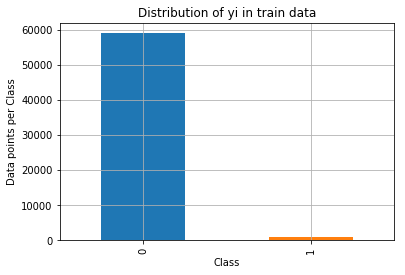

```
Number of data points in class 1 : 59000 ( 98.333 %)
Number of data points in class 2 : 1000 ( 1.667 %)
--------------------------------------------------------------------------------
```

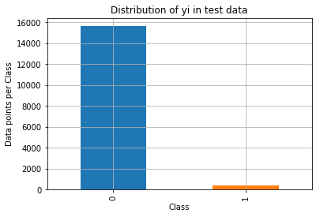

```
Number of data points in class 1 : 15625 ( 97.656 %)
Number of data points in class 2 : 375 ( 2.344 %)
```

```python
# it returns a dict, keys as class labels and values as the number of data points in that class
train_class_distribution = train_data['class'].value_counts().sortlevel()
test_class_distribution = test_data['class'].value_counts().sortlevel()

train_class_distribution.plot(kind='bar')
plt.xlabel('Class')
plt.ylabel('Data points per Class')
plt.title('Distribution of yi in train data')
plt.grid()
plt.show()

sorted_yi = np.argsort(-train_class_distribution.values)
for i in sorted_yi:
    print('Number of data points in class', i+1, ':',train_class_distribution.values[i], '(', np.round((train_class_distribution.values[i]/train_data.shape[0]*100), 3), '%)')


print('-'*80)
my_colors = 'rgbkymc'
test_class_distribution.plot(kind='bar')
plt.xlabel('Class')
plt.ylabel('Data points per Class')
plt.title('Distribution of yi in test data')
plt.grid()
plt.show()

sorted_yi = np.argsort(-test_class_distribution.values)
for i in sorted_yi:
    print('Number of data points in class', i+1, ':',test_class_distribution.values[i], '(', np.round((test_class_distribution.values[i]/test_data.shape[0]*100), 3), '%)')
```

### Distribution of class label is almost same for train and test

```python
# checking the Null for train data:-
train_data.isnull().values.any()
```

```
False
```

- no data is missing in train set

```python
# checking the Null for test data:-
test_data.isnull().values.any()
```

```
False
```

- no data is missing in test set

### Normalizing the whole data.

- helps in getting rid of scale

```python
# train
train_yi = train_data['class']
train_data.drop(['class'],axis=1,inplace=True)
train_data = normalize(train_data)
```

```python
# test
test_yi = test_data['class']
test_data.drop(['class'],axis=1,inplace=True)
test_data = normalize(test_data)
```

```python
# This function plots the confusion matrices given y_i, y_i_hat.
def plot_confusion_matrix(test_y, predict_y):
    C = confusion_matrix(test_y, predict_y)

    A =(((C.T)/(C.sum(axis=1))).T)

    B =(C/C.sum(axis=0))

    labels = [0,1]

    # representing A in heatmap format
    print("-"*20, "Confusion matrix", "-"*20)
    plt.figure(figsize=(4,3))
    sns.heatmap(C, annot=True, cmap="YlGnBu", fmt=".3f", xticklabels=labels, yticklabels=labels)
    plt.xlabel('Predicted Class')
    plt.ylabel('Original Class')
    plt.show()

    print("-"*20, "Precision matrix (Columm Sum=1)", "-"*20)
    plt.figure(figsize=(4,3))
    sns.heatmap(B, annot=True, cmap="YlGnBu", fmt=".3f", xticklabels=labels, yticklabels=labels)
    plt.xlabel('Predicted Class')
    plt.ylabel('Original Class')
    plt.show()

    # representing B in heatmap format
    print("-"*20, "Recall matrix (Row sum=1)", "-"*20)
    plt.figure(figsize=(4,3))
    sns.heatmap(A, annot=True, cmap="YlGnBu", fmt=".3f", xticklabels=labels, yticklabels=labels)
    plt.xlabel('Predicted Class')
    plt.ylabel('Original Class')
    plt.show()
```

# performing over_sampling to get rid of class imbalance

```python
def SMOTE_oversmapling(X, Y):
    sm = SMOTE(ratio = 1.0)
    X_ovs,Y_ovs = sm.fit_sample(X, Y)
    print(X_ovs.shape, Y_ovs.shape)
    print(np.bincount(Y_ovs))
    return X_ovs, Y_ovs
```

```python
train_data , train_yi = SMOTE_oversmapling(train_data, train_yi)
```

```
(118000, 170) (118000,)
[59000 59000]
```

```python
print("train data shape",train_data.shape,train_yi.shape)
print("test data shape",test_data.shape,test_yi.shape)
```

```
train data shape (118000, 170) (118000,)
test data shape (16000, 170) (16000,)
```

## Performing xgboost for binary classification

```python
x_cfl=XGBClassifier()
prams={'n_estimators':[100,200,500,1000],
     'max_depth':[3,5,10,20]}
grid_clf = GridSearchCV(x_cfl,prams,scoring='neg_log_loss',cv=5,n_jobs=-1)
grid_clf.fit(train_data,train_yi)
```

```
GridSearchCV(cv=5, error_score='raise-deprecating',
             estimator=XGBClassifier(base_score=0.5, booster='gbtree',
                                     colsample_bylevel=1, colsample_bynode=1,
                                     colsample_bytree=1, gamma=0,
                                     learning_rate=0.1, max_delta_step=0,
                                     max_depth=3, min_child_weight=1,
                                     missing=None, n_estimators=100, n_jobs=1,
                                     nthread=None, objective='binary:logistic',
                                     random_state=0, reg_alpha=0, reg_lambda=1,
                                     scale_pos_weight=1, seed=None, silent=None,
                                     subsample=1, verbosity=1),
             iid='warn', n_jobs=-1,
             param_grid={'max_depth': [3, 5, 10, 20],
                         'n_estimators': [100, 200, 500, 1000]},
             pre_dispatch='2*n_jobs', refit=True, return_train_score=False,
             scoring='neg_log_loss', verbose=0)
```

```python
cv_logloss = grid_clf.cv_results_['mean_test_score']
cv_logloss = cv_logloss.reshape(4,4)
```

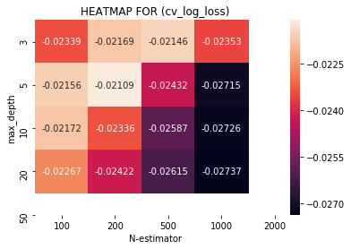

```python
sns.heatmap(cv_logloss,annot=True,fmt=".5f",xticklabels=[100,200,500,1000,2000], yticklabels=[3,5,10,20,50],)
plt.xlabel("N-estimator")
plt.ylabel("max_depth")
plt.title("HEATMAP FOR (cv_log_loss)")
plt.show()
```

*Best parameters are:-*

- **max_depth = 5**
- **n_estimators = 200**

```
train loss 0.00928306228045897
test loss 0.03878100206355702
-------------------- Confusion matrix --------------------
```

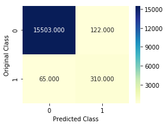

```
-------------------- Precision matrix (Columm Sum=1) --------------------
```

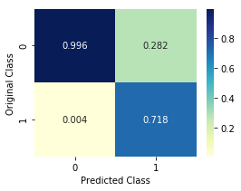

```
-------------------- Recall matrix (Row sum=1) --------------------
```

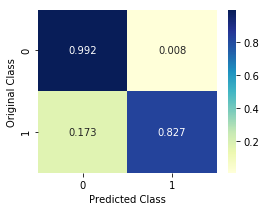

```python
x_clf = XGBClassifier(n_estimators=200,colsample_bytree=0.3,subsample=1,max_depth=5)
x_clf.fit(train_data,train_yi)
c_cfl=CalibratedClassifierCV(x_clf,method='sigmoid')
c_cfl.fit(train_data,train_yi)

predict_y = c_cfl.predict_proba(train_data)
print ('train loss',log_loss(train_yi, predict_y))

predict_y = c_cfl.predict_proba(test_data)
print ('test loss',log_loss(test_yi, predict_y))
plot_confusion_matrix(test_yi,c_cfl.predict(test_data))
```

```python
# save the model to disk
filename = 'final_model_1.sav'
pickle.dump(c_cfl, open(filename, 'wb'))
```

```python
# load the model from disk
loaded_model = pickle.load(open(filename, 'rb'))
```

```python
sample_positive += 0.000001
sample_negative += 0.000001
```

```python
predict_y_pos = loaded_model.predict(sample_positive)
predict_y_pos
```

```
array([1, 1, 1, 1, 1, 1, 1, 0, 1, 1], dtype=int64)
```

```python
predict_y_neg = loaded_model.predict(sample_negative)
predict_y_neg
```

```
array([0, 0, 1, 0, 0, 0, 0, 0, 0, 0], dtype=int64)
```